# Day 9: Actor Effects and Relational Roles

The Social Relations Model (SRM) and Blockmodels

Shahryar Minhas

## What Changes Today

Day 8

We built defensible network objects and saw why dyads sharing actors are not independent rows.

Day 9

We ask whether a few actors repeatedly appear across many relationships, whether cooperation centers on a small tactical core, and whether defense partners changed along different paths after the Cold War.

Start with what may be missing from the story, then choose the model that can represent it.

Open the walkthrough

## The Syrian Cooperation Case

Gade et al. (2019) study armed organizations operating in the Syrian rebellion from July 2012 through June 2015. The network includes organizations such as Al-Nusrah Front (ANF) and Ahrar al-Sham Islamic Movement (ASIM).

- Why did some pairs cooperate more than others?
- Were some organizations unusually active across many partnerships?
- Was cooperation spread broadly, divided into separate camps, or organized around a small tactical core?

The main question comes first: how was tactical cooperation organized within a fragmented opposition?

Meet the Syrian cooperation data

## What Counts as Cooperation?

The outcome is the number of claimed joint tactical operations between two organizations. We model its square root, following the published application.

Observed pair attributes

- Ideological distance, 0 to 4 points
- Power difference, in thousands of fighters
- Shared operational location, yes or no
- Shared state sponsorship, yes or no

Observed organization attributes

- Average ideology
- Organizational size
- Presence of state sponsorship

The relationship is symmetric: a joint operation belongs to the pair, not to a sender and receiver.

Inspect the data and coding

## Use `netify` to Build the Network Inputs

```r
gade_net <- netify(
  input = gade,
  actor1 = "actor1",
  actor2 = "actor2",
  symmetric = TRUE,
  weight = "sqrt_coop",
  nodal_vars = c("averageId_actor1", "size_actor1", "spons_actor1"),
  dyad_vars = c("ideol_diff", "powerdiff", "loc", "spons"),
  dyad_vars_symmetric = rep(TRUE, 4),
  missing_to_zero = TRUE
)

gade_lame <- to_lame(gade_net, family = "normal")
```

`netify` turns the pair-level table into one symmetric outcome matrix, one dyadic predictor array, and one row of actor attributes per organization.

The data bridge preserves who appears in each relationship. That repeated-actor structure is exactly what the SRM needs.

Build the network inputs

## Start With the Expectations

| Mechanism | Expected pattern |
| --- | --- |
| Ideological compatibility | Greater ideological distance, less cooperation |
| Preference for similarly strong partners | Greater power difference, less cooperation |
| Opportunity | Shared location, more cooperation |
| Patron coordination | Shared sponsor, more cooperation |

These are observational associations. A network model does not create random assignment.

## The Models Answer Different Questions

| Model | Question | What We Learn |
| --- | --- | --- |
| Independent regression | Which measured attributes predict cooperation? | A benchmark that treats pairs as fresh rows |
| SRM | Which organizations took part in more joint operations across many partners than the measured characteristics predict? | An adjusted cooperation score for each organization |
| Cross-sectional stochastic blockmodel (SBM) | Is cooperation spread broadly, divided into camps, or centered on a few widely connected organizations? | A summary of how often organizations in each fitted role worked with one another |
| Longitudinal SRM | Which states appeared in many above-threshold ICEWS relationships as the coded source or target, and when did that change? | Separate yearly summaries for events coded from and toward each state |
| Repeated-network NetMix | Did Poland, Romania, and Russia develop similar defense partners after the Cold War, or did their treaty networks take different paths? | A yearly comparison of each state’s defense-partner list |

Use the model compass

## Why Independent Dyads Are Not Credible Here

The pairs `ANF-ASIM` and `ANF-ISIL` both contain ANF.

If ANF has unmeasured organizational capacity, both observations inherit it.

Let $\epsilon_{ij}$ be what the independent regression still gets wrong for pair $ij$. Then

$$\epsilon_{\text{ANF,ASIM}} \not\perp \epsilon_{\text{ANF,ISIL}}$$

The crossed independence symbol, $\not\perp$, means the two remaining errors are not statistically independent.

Pairs involving the same organization are not separate pieces of evidence, even when every unordered pair appears only once.

Run the independent benchmark

## Put the Residuals Back Into the Network

For each organization, average the residuals from all of its partnerships.

Independent model works

Organization-level residual means cluster around zero.

Recurring Organization Pattern

The same organizations repeatedly sit above or below the regression line.

Inspect recurring residual structure

## The Symmetric SRM Adds One Actor Effect

$$\begin{aligned}
y_{ij}&=\mathbf{x}_{ij}^{\mathsf T}\boldsymbol\beta+a_i+a_j+\epsilon_{ij},\\
a_i&\stackrel{\mathrm{iid}}{\sim}\mathcal N(0,\sigma_a^2).
\end{aligned}$$

$\mathbf x_{ij}$ contains the measured pair attributes, $\boldsymbol\beta$ contains their coefficients, and $\epsilon_{ij}$ is what remains unique to the pair.

The label $\mathrm{iid}$ means independent and identically distributed across organizations: the actor effects use the same distribution but are separate draws.

$a_i$

Whether organization $i$ records more or fewer joint operations across its partners than the measured variables predict.

$\sigma_a^2$

How much the organizations differ in that adjusted level of cooperation.

Build the symmetric SRM

## Directed SRM: Same Logic, More Pieces

$$\begin{aligned}
y_{ij}&=\mathbf{x}_{ij}^{\mathsf T}\boldsymbol\beta+a_i+b_j+\epsilon_{ij},\\
\begin{pmatrix}a_i\\b_i\end{pmatrix}
&\stackrel{\mathrm{iid}}{\sim}\mathcal N\!\left[
\begin{pmatrix}0\\0\end{pmatrix},
\begin{pmatrix}\sigma_a^2&\sigma_{ab}\\\sigma_{ab}&\sigma_b^2\end{pmatrix}
\right],\qquad
\operatorname{Corr}(\epsilon_{ij},\epsilon_{ji})=\rho .
\end{aligned}$$

- $a_i$: how often actor $i$ appears on the source side, beyond the measured predictors
- $b_i$: how often the same actor appears on the target side
- $\sigma_a^2$ and $\sigma_b^2$: how much the adjusted source-side and target-side scores differ across actors
- $\sigma_{ab}$: whether states that are often sources are also often targets
- $\rho$: whether an unexpectedly high $i\!\rightarrow\!j$ outcome accompanies an unexpectedly high $j\!\rightarrow\!i$ outcome

Use the symmetric form for joint operations and the directed form when the action has a meaningful direction.

## Omitted Actor Structure and the SRM

Suppose the relationship really follows:

$$y_{ij}=\beta x_{ij}+a_i+a_j+\epsilon_{ij}.$$

If we omit the actor effects:

$$\operatorname{plim}(\widehat\beta_{\text{naive}})
=\beta+\frac{\operatorname{Cov}(x_{ij},a_i+a_j)}
{\operatorname{Var}(x_{ij})}.$$

The standard random-effects SRM assumes that the remaining actor effect has conditional mean zero given the included predictors:

$$\operatorname{E}(a_i\mid X)=0.$$

If a predictor systematically varies with the actor effects, the random-effects assumption fails and the coefficient can mix the predictor association with recurring actor differences.

Work through the inference cases

## Positive Covariance Case

Let $x$ be ideological distance. Suppose organizations with high positive actor effects are disproportionately involved in ideologically distant pairs.

Then $\operatorname{Cov}(x_{ij},a_i+a_j)>0$, so the independent model credits ideological distance with some of the broad organizational activity.

Ideological distance can look less negatively associated with cooperation than it does after recurring actor activity enters, appear unrelated, or even appear positively associated.

Positive covariance pulls the naive ideology coefficient upward in this setup.

## Negative Covariance Case

Keep $x$ as ideological distance. Suppose organizations with high positive actor effects are concentrated in ideologically similar pairs.

Then $\operatorname{Cov}(x_{ij},a_i+a_j)<0$, so the independent-model ideology coefficient is pulled downward.

Ideological distance can look more negatively associated with cooperation than it does after broad recurring organization activity enters.

Negative covariance pulls the naive ideology coefficient downward in this setup.

## Zero Covariance Case

If $\operatorname{Cov}(x_{ij},a_i+a_j)=0$, the independent-model ideology coefficient can still be centered on $\beta$.

The errors are still dependent because relationships sharing organizations inherit the same actor effects.

A coefficient can approach the right target while the independent-row uncertainty calculation remains wrong.

## What the Random-Effects SRM Assumes

Adding actor effects represents relationships that share actors, but the usual SRM still assumes the remaining actor effects are unrelated to the included predictors after conditioning on the model.

- If an actor effect and a covariate remain correlated, $\operatorname{E}(a_i\mid X)=0$ is violated.
- The coefficient can then blend stable actor differences with the measured predictor.
- With one cross-sectional network, we cannot compare the same actor with itself over time.
- A badly chosen control variable remains a problem after actor effects enter.

The SRM models an important dependence source. It does not make actor effects exogenous by estimation alone or create a causal design.

Read the inferential boundary

## A Concise Mundlak Remedy

For a time-varying predictor, separate within-actor change from stable between-actor differences:

$$x_{it}=(x_{it}-\bar x_i)+\bar x_i.$$

Include the actor mean $\bar x_i$ in the model, with separate source and target means in a directed network. The remaining random effect is then assumed unrelated to the within-actor deviation rather than to the raw predictor.

Also measure the missing mechanism when possible, compare fixed-effects specifications when the needed variation exists, and report sensitivity across defensible models.

Mundlak terms relax the standard random-effects assumption in a specific way. They do not remove pair-level confounding or create a causal design.

## What the SRM Sampler Is Trying to Learn

The observed network has to inform four connected pieces:

- Associations with the measured variables, $\boldsymbol\beta$
- One adjusted cooperation effect for every organization, $\mathbf a$
- How much those organization effects vary, $\sigma_a^2$
- How much pair-level variation remains, $\sigma_\epsilon^2$

$$p(\boldsymbol\beta,\mathbf a,\sigma_a^2,\sigma_\epsilon^2\mid Y,X)
\propto
\underbrace{p(Y\mid X,\boldsymbol\beta,\mathbf a,\sigma_\epsilon^2)}_{\text{fit to the observed partnerships}}
\times
\underbrace{p(\boldsymbol\beta,\mathbf a,\sigma_a^2,\sigma_\epsilon^2)}_{\text{regularization and pooling}}$$

Parameter settings receive more posterior weight when they explain the observed partnerships without requiring implausible coefficients or actor effects.

## How MCMC Explores That Target

One sweep updates connected blocks:

1. Draw coefficients conditional on the current actor effects.
2. Draw organization effects conditional on their partnerships and the current coefficients.
3. Draw the actor-effect and remaining-error variances.
4. Repeat, discard burn-in, and summarize the retained draws.

The sampler does not maximize the posterior and stop at one value. Its retained draws represent the posterior distribution.

A trace plot checks the sampler’s movement. A credible interval summarizes uncertainty under the model. Neither one proves that the model or exogeneity assumption is correct.

Walk through the MCMC target and cycle

## One Switch Separates the Benchmark and SRM

```r
# Independent pairs
ame(..., symmetric = TRUE, nvar = FALSE)

# Persistent organization effects
ame(..., symmetric = TRUE, nvar = TRUE)
```

The models use the same outcome, predictors, likelihood, shared-parameter priors, and MCMC settings. The SRM adds the actor effects and their variance prior.

Run the fitted models

## Read Point Estimates and Intervals Separately

- Greater ideological distance has a negative point estimate, but its SRM interval crosses zero.
- A larger difference in estimated fighters has a negative estimate, and its SRM interval stays below zero.
- Shared operating location has a positive point estimate, but its interval crosses zero.
- Shared state sponsorship remains uncertain.

The clearest SRM result is that organizations closer in estimated strength carried out more claimed joint operations, conditional on the included variables and recurring organization activity.

Compare the coefficients

## The Actor Effects Describe Named Organizations

The model gives Al-Nusrah Front (ANF) and Ahrar al-Sham Islamic Movement (ASIM) the two highest adjusted cooperation scores.

They participated in more recorded joint operations across their partnerships than we would expect from the measured ideology, power, location, sponsorship, and organization characteristics alone.

Inspect the organization effects

## The SRM Is Already a Latent-Variable Model

The effect $a_i$ is inferred from the network rather than observed directly.

Represent Recurring Differences

Keep the measured variables from having to explain every recurring difference among organizations.

A Clue Worth Following

See which organizations take part in unusually many recorded joint operations across their partnerships, then investigate what capacity or position may explain it.

A label for a latent effect must be validated with information beyond the fitted network.

Use the SRM as a latent tool

## Posterior Predictive Checks Show the SRM Boundary

What the SRM Reproduces

Uneven activity across organizations: observed 0.44, fitted median 0.41

What the SRM Misses

Standardized triple-pattern statistic: observed 0.21, fitted median -0.03

The SRM captures which organizations cooperate broadly but misses the observed tendency for high cooperation values to cluster across connected triples.

Inspect the SRM posterior predictive checks

## Where These Methods Come From

- Back and Kenny (2010): the general SRM decomposition
- Hoff (2005): network regression with additive actor effects
- Gade et al. (2019): ideology and tactical cooperation among Syrian armed organizations
- Minhas et al. (2022): dyadic dependence and omitted-variable limits
- Boschee et al. (2015): ICEWS event coding and source-target records
- Olivella, Pratt, and Imai (2022): mixed-membership models for repeated networks

These sources connect the models, data construction, and interpretations used today.

See the reading bridge

## From Actor Effects to Discrete Roles

The SRM gives every organization one adjusted score for how broadly it cooperates. The blockmodel asks a different question: was cooperation spread evenly, divided into separate camps, or organized around a small set of organizations that worked across a much less connected field?

This analysis uses the 31 organizations with at least one recorded cooperation tie. The SRM used square-root counts for the 30 organizations with complete covariates.

The question changes from “Who worked with unusually many partners?” to “Was the network organized around a small tactical core?”

Move from effects to roles

## Blocks Are Not Necessarily Communities

Community

Dense cooperation within a group and sparse cooperation across groups.

Core-periphery roles

Dense core, extensive core-to-periphery cooperation, sparse cooperation within the periphery.

Read all within-role and across-role rates. Dense diagonal cells are only one possible relational structure.

## A Role Is a Compressed Partner List

Imagine describing the network with only three numbers:

- How often core organizations cooperate with one another
- How often core and peripheral organizations cooperate
- How often peripheral organizations cooperate with one another

We also need one role assignment for each organization. If those few quantities reconstruct the partner lists well, they provide a useful summary of the network.

The model groups organizations whose ties and non-ties follow similar patterns. It does not begin with substantive labels or assume that every role is a community.

## The Blockmodel Names the Pieces

$$Y_{ij}\mid z_i,z_j\sim\operatorname{Bernoulli}(\theta_{z_i z_j})$$

- $z_i$ is organization $i$’s relational role.
- $\theta_{gh}$ is the probability of a recorded tie between roles $g$ and $h$.
- The full $\boldsymbol\theta$ matrix contains every within-role and across-role probability.

The role labels are arbitrary. Their substantive meaning comes from the fitted relationship matrix and the organizations assigned to each role.

Read the cross-sectional blockmodel

## What the Blockmodel Likelihood Rewards

$$L(\mathbf z,\boldsymbol\theta;Y)
=\prod_{i<j}
\theta_{z_i z_j}^{Y_{ij}}
(1-\theta_{z_i z_j})^{1-Y_{ij}}$$

- A recorded tie rewards assignments with a large relevant $\theta_{z_i z_j}$.
- A recorded non-tie rewards assignments with a small relevant $\theta_{z_i z_j}$.
- The preferred roles make entire partner lists unsurprising, not merely actor degrees.

The estimator seeks a role assignment and probability matrix that make the observed pattern of ties and non-ties likely.

See what the likelihood is measuring

## How Variational EM Fits the Blockmodel

1. Begin with tentative role probabilities for every organization.
2. Update each organization’s probabilities using its ties, non-ties, and the current role-pair rates.
3. Update each role-pair rate as a membership-weighted proportion of observed ties.
4. Alternate until the evidence lower bound stops improving.
5. Repeat from several starts because the objective has local optima.

$$\operatorname{ELBO}
=E_q[\log p(Y,\mathbf z\mid\boldsymbol\theta)]
-E_q[\log q(\mathbf z)]$$

`blockmodels` approximately maximizes the observed-data likelihood. It returns a fast variational fit, not MCMC draws from a posterior.

Walk through the objective and updates

## Two Roles Best Balance Simplicity and Fit

The integrated completed likelihood, or ICL, rewards fit and penalizes unnecessary roles. Higher is better here. It prefers $K=2$ roles, but the $K=3$ solution is close enough to inspect. Here $K$ is the number of roles.

The score helps us choose, but it does not reveal a single true number of groups. We look for the finding that survives nearby choices and different starting values.

Inspect ICL and nearby models

## The Stable Core Is ANF and ASIM

Across the two- and three-block solutions, Al-Nusrah Front (ANF) and Ahrar al-Sham Islamic Movement (ASIM) remain together in the core.

The other organizations occupy one broad periphery or two peripheral roles with different access to the core.

ANF and ASIM form a small tactical backbone with links across much of this observed cooperation network. That does not make the opposition one unified coalition.

See who occupies each role

## Read the Cooperation Probabilities as Actions

Observed ties and approximate fitted probabilities:

- Core with core: 1 of 1 observed, fitted 0.96
- Core with periphery: 44 of 58 observed, fitted 0.73
- Periphery with periphery: 41 of 406 observed, fitted 0.10

The strongest evidence is the breadth of core-to-periphery cooperation. The 0.96 core estimate comes from only one possible core pair.

Interpret the block matrix

## Compare the Observed Network With the Role Model

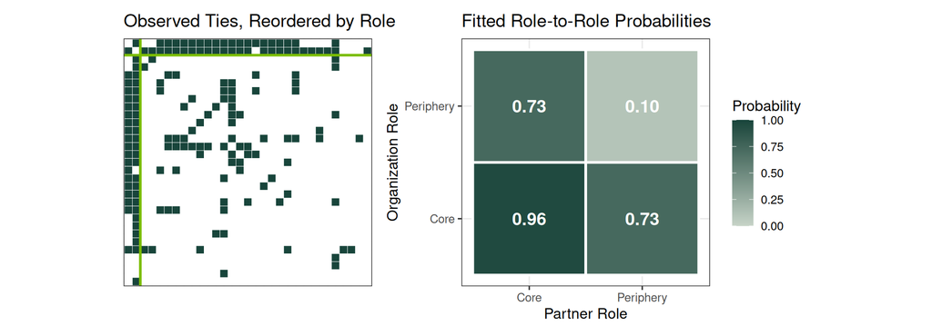

Observed matrix: individual ties. Heat map: fitted probabilities for core-core, core-periphery, and periphery-periphery ties.

Open both block plots

## Simulate Networks From the Fitted Roles

- Spread in the number of partners: 5.43 observed, 4.72 in an average fitted simulation
- Three-organization cooperation triangles: 99 observed, about 61 in an average fitted simulation

The two roles capture the broad core-periphery shape, but they produce too few triangles and slightly too little variation in how many partners organizations have.

Run the block fit check

## Two Longitudinal Questions Need Different Panels

| Question | Data | Model |
| --- | --- | --- |
| How do states’ adjusted source-side and target-side positions change across years? | 13 directed annual networks | Dynamic SRM with `lame` |
| Which states have similar alliance portfolios, and whose portfolio changes? | 10 undirected annual defense-alliance networks | Repeated-network `NetMix` |

The outcome equals one when an ICEWS source-target dyad records more than 20 materially conflictual events in a year.

Polity scores run from -10 for strongly autocratic regimes to 10 for strongly democratic regimes. We divide the absolute gap by 20, so a 10-point difference enters the model as 0.5.

The SRM needs source and target positions. NetMix needs partner patterns that can reveal more than a degree ranking.

Build the longitudinal panel

## The Binary Longitudinal SRM

$$\Pr(Y_{ijt}=1)=\Phi\!\left(\alpha_t+\mathbf{x}_{ijt}^{\mathsf T}\boldsymbol\beta+a_{it}+b_{jt}\right)$$

- Year intercepts absorb changes in overall above-threshold network density.
- $\Phi$ turns the fitted probit score into a probability between zero and one.
- $\alpha_t$ gives each year its own baseline rate, while $\mathbf{x}_{ijt}^{\mathsf T}\boldsymbol\beta$ contains the measured dyad-year predictors.
- $a_{it}$ records how often state $i$ appears as the coded source in year $t$ beyond those predictors.
- $b_{jt}$ records how often state $j$ appears as the coded target in year $t$ beyond those predictors.
- `dynamic_ab = TRUE` links adjacent annual scores with an AR(1)-style smoothing penalty.

Fit the binary longitudinal SRM

## What Dynamic ALS Is Trying to Fit

```r
lame(...,
  family = "binary",
  method = "als",
  dynamic_ab = TRUE,
  bootstrap = 100,
  bootstrap_type = "parametric")
```

The binary outcome is converted into a temporary probit working score. The estimator finds coefficients and annual source and target effects that reconstruct those scores while keeping adjacent annual paths reasonably smooth.

This is a penalized point estimate. It is not an MCMC posterior and does not maximize the exact binary likelihood.

Read the estimator boundary

## What Dynamic ALS Minimizes

$$\sum_{t,i\ne j}w_{ijt}
\left[z_{ijt}-(\mathbf x_{ijt}^{\mathsf T}\boldsymbol\beta+a_{it}+b_{jt})\right]^2
+\lambda_a\sum_{t>1}\|\mathbf a_t-\rho\mathbf a_{t-1}\|^2
+\lambda_b\sum_{t>1}\|\mathbf b_t-\rho\mathbf b_{t-1}\|^2$$

1. Update the probit working responses $z$ and weights $w$.
2. Solve for the measured coefficients.
3. Update the annual source and target paths.
4. Repeat until the penalized objective stops changing.

The first term rewards reconstruction of the observed zeroes and ones. The last two terms penalize unnecessarily jagged actor paths.

## Measured Associations and Bootstrap Intervals

| Predictor | Probit coefficient | 95% bootstrap interval |
| --- | --- | --- |
| Polity gap, 0 to 20 points | 0.881 | [0.698, 1.268] |
| Same region | 1.451 | [1.400, 1.722] |

Both associations are positive in this selected panel. The coefficients move a latent probit score, so they are not percentage-point changes.

Use the fitted probability contrasts in the walkthrough to discuss ordinary units. Those comparisons are not observed changes within a pair or causal effects.

Inspect the longitudinal SRM results

## Events Coded From and Toward Each State

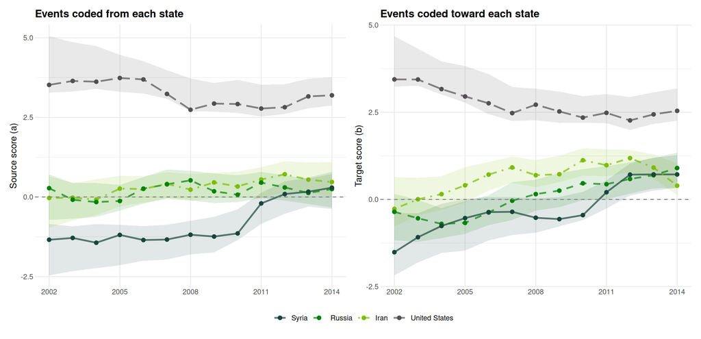

Read the left panel as events coded from each state and the right panel as events coded toward each state. The line is the dynamic ALS estimate; the shaded area comes from 100 parametric-bootstrap refits.

Open the plot beside the code

## Syria’s Adjusted Source and Target Scores Changed

The fitted score for events coded **from Syria** rises:

- 2002: -1.34, with 95% bootstrap interval [-2.46, -0.85]
- 2012: 0.09, with interval [-0.53, 0.49]
- 2014: 0.29, with interval [-0.38, 0.79]

The fitted score for events coded **toward Syria** rises more sharply:

- 2002: -1.51, with interval [-2.18, -0.39]
- 2012: 0.71, with interval [0.11, 1.04]
- 2014: 0.72, with interval [0.33, 1.27]

After 2011, Syria appears in many more relationships that cross the 20-event cutoff, especially as the state toward which ICEWS coded the events.

Open the dynamic trajectories

## The Other Focus States

- The United States stays clearly above zero for events coded both from it and toward it throughout 2002 to 2014.
- Iran is clearly above zero for events coded toward it from 2006 onward, with especially high values from 2010 through 2013.
- Russia is clearly above zero for events coded toward it from 2012 through 2014.

These paths describe which states appear in many above-threshold ICEWS relationships after the included predictors enter. They do not measure military initiation, victimization, or conflict severity.

Compare the four states

## What the Bootstrap Ribbons Mean

For each of 100 bootstrap replications:

1. Generate a new 13-year panel from the fitted dynamic SRM.
2. Refit the same model to that generated panel.
3. Save the annual trajectories for events coded from and toward each state.
4. Use the spread across refits to build the ribbons.

The ribbons show how much the fitted paths vary across panels generated by this SRM. They are not Bayesian credible intervals, design-based intervals, or protection against model misspecification.

Inspect the bootstrap procedure

## What This Dynamic SRM Does Not Show

The AR(1)-style penalty smooths adjacent annual actor effects. It does not identify the process that produced a rise or fall.

The model does not give every state pair its own long-run baseline, include a lagged outcome, or show that a source-side change caused a target-side change.

The trajectories describe changing adjusted positions in this selected coded-event panel, not changes in conflict severity or a causal response process.

## Did Post-Cold War Defense Partners Follow the Same Path?

Did Poland, Romania, and Russia develop similar sets of defense partners after the Cold War, or did their treaty networks take different paths? Which states connected partner systems that would otherwise remain separate?

The panel contains 50 states from 1991 through 2000. A tie means the pair had a recorded defense commitment in that year.

The model compares where alliances go, not simply how many each state has.

Meet the defense-alliance panel

## What NetMix Learns

1. A table showing how often every pair of roles contains an alliance
2. Three weights for each state-year showing how much its partner list resembles each role

The three weights add to one. A state-year can mix roles rather than receiving one permanent label.

A role is a recurring kind of partner list. It is not a hidden personality or a permanent camp.

Walk through the role model

## Turn the Notation Into One Sentence

$$\Pr(Y_{ijt}=1)
=\sum_g\sum_h\pi_{it,g}\pi_{jt,h}\theta_{gh}
=\boldsymbol\pi_{it}^{\mathsf T}\boldsymbol\Theta\boldsymbol\pi_{jt}$$

- $\pi_{it,g}$: how much state $i$ in year $t$ resembles role $g$
- $\pi_{jt,h}$: how much state $j$ in that year resembles role $h$
- $\theta_{gh}$: how often role $g$ and role $h$ are allied

Ask how much each state resembles each pattern, look up how strongly those patterns connect, and combine the answers.

## How One State-Year Informs Its Role Mixture

Take Poland in 1997. The estimator examines:

- Every state with which Poland recorded a defense commitment
- Every state with which it did not
- The current alliance rates among the three candidate roles

It asks which mixture of regional, dense-multilateral, and sparse partner patterns makes that entire treaty list least surprising.

NetMix is not assigning a role from Poland’s degree alone. Two states with the same number of treaties can receive different mixtures when their partners occupy different roles.

## How Variational Inference Fits NetMix

1. Begin with rough role weights for every state-year.
2. Update approximate role assignments for the endpoints of every dyad.
3. Update state-year membership vectors and role-pair alliance log-odds.
4. Continue until the evidence lower bound stops improving.

$$\operatorname{ELBO}
=E_q[\log p(Y,\text{roles},\boldsymbol\pi\mid\boldsymbol\Theta)]
-E_q[\log q(\text{roles},\boldsymbol\pi)]$$

The ELBO rewards explaining the treaty panel while tracking uncertainty in the approximate latent assignments. It is not a probability or a goodness-of-fit test.

Read the estimator explanation

## One Hidden State Means No Transition Model

Every state-year receives three role weights, and all ten years share one role-to-role alliance table.

With `n.hmmstates = 1`, there is no transition matrix, smoothing, or estimated switching process.

We can compare yearly partner profiles. We cannot say the model learned how states move from one profile to another.

## The Fitted Alliance Pattern

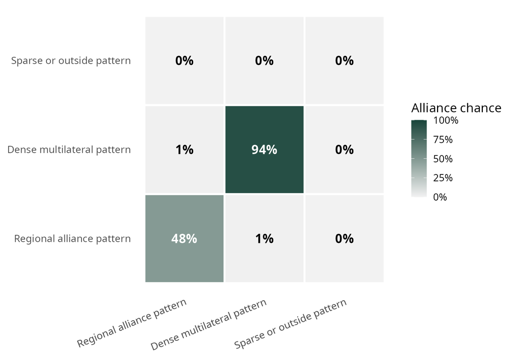

The recorded treaties form one tightly connected multilateral system, one moderately connected regional system, and a set of state-years with few ties into either system.

Open the role-matrix heat map

## Why Mixed Membership Matters

- The United States mixes the regional and dense multilateral patterns early in the panel, so forcing it into only one role would discard part of its alliance portfolio.
- Poland and Romania both have few ties into the two connected systems early in the decade.
- From 1997 onward, Poland’s partners are mainly states already tied into the dense multilateral system, while Romania’s partner list does not make the same move.

The weights preserve overlap and change that a hard one-block-per-state assignment would hide.

Inspect the yearly role profiles

## What the Profiles Show

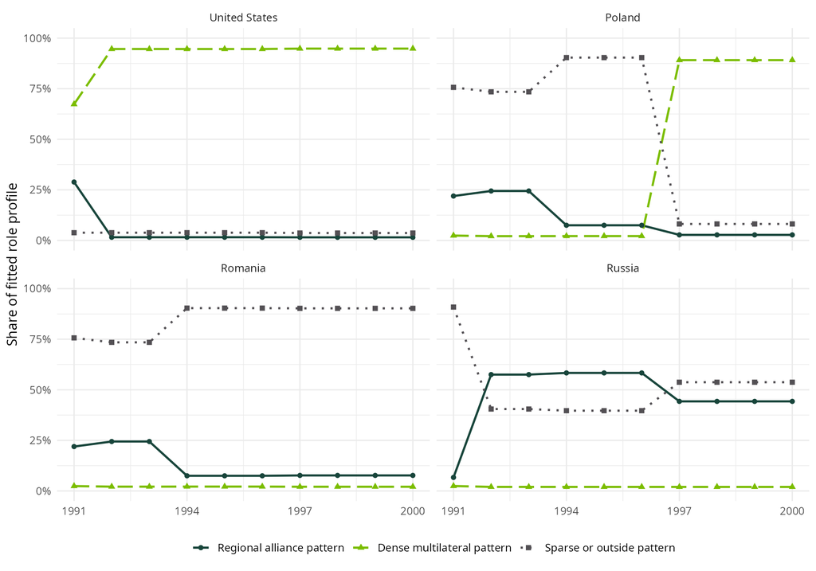

The plot shows three different paths: Poland’s partners move into the dense multilateral system, Romania remains connected to relatively few states in this panel, and Russia’s partners concentrate in a different regional system.

Open the accessible profile plot

## How Much Does It Add Beyond Degree?

Dense-role membership correlates about 0.90 with the number of alliances a state-year has, so much of the result is a density ranking.

Partner identities still add something. Poland and Romania begin with similarly short partner lists, then separate when Poland forms defense commitments with states already connected to the dense multilateral system and Romania does not.

This supports a comparison of the Poland, Romania, and Russia paths, not a claim that the fitted roles are permanent types of states.

## Does the Model Recreate the Alliances We Gave It?

The Brier score is the average squared gap between an estimated alliance probability and the observed zero or one. Lower is better.

| Prediction | Brier score |
| --- | --- |
| Three-role NetMix fit | 0.038 |
| Same alliance chance for every pair-year | 0.084 |

Using the three partner-list patterns produces much smaller probability errors than giving every state pair the same alliance chance. This checks the records used to fit the model, not new years.

Open the reconstruction code

## Boundaries on the Interpretation

- Role weights summarize recorded treaty partners, not treaty credibility or compliance.
- The role labels are descriptions, not natural kinds.
- Three roles were set before estimation.
- One hidden state means no estimated transition process.
- Role numbers must be aligned before comparing separate fits.
- The model describes this 50-state panel, not every state in the system.

The model shows which states had similar defense partners and when those partner lists changed. It does not explain why they changed.

## Three Ways to Represent the Missing Pattern

| Model | How It Represents What We Did Not Measure |
| --- | --- |
| SRM | One adjusted activity score for each actor |
| SBM | One relational role for each actor |
| Repeated-network mixed-membership stochastic blockmodel, fitted with NetMix | A separate blend of roles for each actor-year |

Choose the model from the research question and the pattern left in the errors, then check what the model still fails to reproduce.

Compare the representations

## What Happened Among the Syrian Organizations?

The data count claimed joint tactical operations between pairs of armed organizations from July 2012 through June 2015. Pairs closer in estimated fighter strength carried out more of these operations after accounting for ideology, operating location, state sponsorship, and whether each organization cooperated broadly with many partners.

Al-Nusrah Front and Ahrar al-Sham Islamic Movement carried out more claimed joint operations across their many partnerships than the measured variables predicted. In the binary network, these two organizations connected to 44 of 58 possible pairs involving the rest of the network, while the other organizations connected to only 41 of 406 possible pairs among themselves.

They formed a small tactical backbone in the recorded cooperation network. That does not mean they shared long-term goals, formed a unified coalition, or would have cooperated differently if we changed one measured attribute.

Read the complete interpretation

## What Happened in the ICEWS Example?

The outcome is whether ICEWS recorded more than 20 materially conflictual events from one state toward another in a year. The United States crossed that cutoff with many states in both directions from 2002 through 2014.

Syria crossed the cutoff with relatively few states through 2010. After 2011, Syria appeared in many more above-threshold relationships, especially as the state toward which events were directed. The bootstrap intervals show a clear change from its earlier years.

These findings describe a selected panel of coded news events. They may reflect state behavior, news coverage, and coding practices, and they do not measure conflict severity or establish causal effects.

Read the complete interpretation

## What Happened in the Alliance Example?

The treaty records show that Poland, Romania, and Russia did not follow one common post-Cold War path.

From 1997 onward, Poland’s defense partners are mainly states already tied into a dense multilateral system. Romania remains connected to relatively few states in this panel, while Russia’s partners concentrate in a different regional system.

The model makes the three partner lists comparable from year to year. Much of its dense-pattern score still tracks the number of alliances, and it does not explain the realignment or tell us whether every treaty was equally credible.

Read the complete interpretation

## What to Carry Into Day 10

1. Relationships that share an actor are connected, even when each pair appears only once.
2. A missing process can pull a coefficient up, pull it down, or leave it centered while still making the usual uncertainty calculation wrong.
3. A random-effects SRM assumes the remaining actor effects are conditionally unrelated to the predictors; Mundlak terms can relax that assumption in repeated data.
4. SRM actor effects show which actors repeatedly sit above or below the measured prediction. They do not create a causal design.
5. The SRM reproduces broad actor heterogeneity here but misses third-order dependence.
6. Blockmodels find recurring relationship patterns, not automatically substantive communities.
7. Dynamic SRM trajectories describe adjusted source and target prominence in ICEWS; NetMix memberships compare defense-alliance partner profiles.

Return to the walkthrough